# Spring 294A Final Project

Maxwell Lee

6/15/18

## Source of data and project goals

Continuing off of my Winter 294A Final Project, coded in R, I aim to answer the questions about speeding tickets using Python annd Jupyter Notebooks. In the Winter project I cleaned and created a speedingTicket dataset from Traffic_Violations, which contains data on all traffic stops in Montgomery County, Maryland since 2012. The website below contains Traffic_Violations.csv.

https://catalog.data.gov/dataset/traffic-violations-56dda

## Questions

1. What day of the week are the MOST amount of speeding tickets written?
2. What day of the week are the LEAST amount of speeding tickets written?
3. At what hour are the MOST amount of speeding tickets written?
4. For what speed limit zones do officers write the MOST amount of tickets?
5. Do men tend to drive faster than women?

### Import the packages

pandas is a vast data analysis package in Python, much like how we used dplyr in R.

matplotlib contains basic graphics functions.

seaborn is the commonly used data visualizer that wraps matplotlib.

statsmodels is a statistics package and includes methods for regressions.

```python
import pandas as pd
import matplotlib.pyplot as plt
import seaborn as sns
import statsmodels.formula.api as smf
```

### Reading the data in

The code assumes a file structure with the working directory as "../notebooks" and a parallel folder "../data". The .head() method shows you the first five observations in a dataset.

```python
speedingTicket = pd.read_csv('../data/speedingTicket.csv')
speedingTicket.head()
```

|  | Unnamed: 0 | DateTime | Description | Race | Gender | speedingAt | speedLimit | mphOverLimit |
| --- | --- | --- | --- | --- | --- | --- | --- | --- |
| 0 | 1 | 2018-03-21 17:37:00 | EXCEEDING POSTED MAXIMUM SPEED LIMIT: 62 MPH I... | WHITE | F | 62 | 30 | 32 |
| 1 | 2 | 2018-03-21 17:29:00 | EXCEEDING POSTED MAXIMUM SPEED LIMIT: 53 MPH I... | WHITE | M | 53 | 30 | 23 |
| 2 | 3 | 2018-03-21 17:17:00 | EXCEEDING POSTED MAXIMUM SPEED LIMIT: 50 MPH I... | WHITE | F | 50 | 30 | 20 |
| 3 | 4 | 2018-03-21 17:10:00 | EXCEEDING POSTED MAXIMUM SPEED LIMIT: 51 MPH I... | WHITE | M | 51 | 30 | 21 |
| 4 | 5 | 2018-03-21 17:02:00 | EXCEEDING POSTED MAXIMUM SPEED LIMIT: 50 MPH I... | WHITE | M | 50 | 30 | 20 |

### Cleaning up the clutter

From my Winter project, we know that Description comes straight from Traffic_Violations. From there I created speedingAt, speedLimit, and mphOverLimit, so Description is unnecessary. There also appears to be an unnecessary index column Unnamed: 0.

```python
speedingTicket = speedingTicket.drop(columns=['Unnamed: 0', 'Description'])
speedingTicket.head()
```

|  | DateTime | Race | Gender | speedingAt | speedLimit | mphOverLimit |
| --- | --- | --- | --- | --- | --- | --- |
| 0 | 2018-03-21 17:37:00 | WHITE | F | 62 | 30 | 32 |
| 1 | 2018-03-21 17:29:00 | WHITE | M | 53 | 30 | 23 |
| 2 | 2018-03-21 17:17:00 | WHITE | F | 50 | 30 | 20 |
| 3 | 2018-03-21 17:10:00 | WHITE | M | 51 | 30 | 21 |
| 4 | 2018-03-21 17:02:00 | WHITE | M | 50 | 30 | 20 |

### Checking types

To answer the first two questions, count the number of observations for each day of the week, likewise for hours in the third question. In the Winter Project's rdata file, speedingTicket is a dateTime object, but in .csv form it converts back to a basic string object, and this can be verified by the .dtypes method (which checks the types for all variables in the dataset). We want DateTime to actually be a datetime object compatible with pandas so that we can call the day of the week or hour easily.

```python
speedingTicket.dtypes
```

```
DateTime        object
Race            object
Gender          object
speedingAt       int64
speedLimit       int64
mphOverLimit     int64
dtype: object
```

### Converting a string object to a pandas datetime object

Use the .to_datetime() method to convert a properly formatted string object to a datetime. Documention for the multiple date and time formats can be found online.

```python
speedingTicket['DateTime'] = pd.to_datetime(speedingTicket['DateTime'])
speedingTicket.dtypes
```

```
DateTime        datetime64[ns]
Race                    object
Gender                  object
speedingAt               int64
speedLimit               int64
mphOverLimit             int64
dtype: object
```

### Pulling the day of the week

.dt.dayofweek gives the day of the week in a numerical form. Online documentation says that 0 is Monday, and 6 is Sunday, so change that to the actual English for ease of readability. Do this with keys and values, creating a dictionary called dayOfWeek. The .map() method "translates" your numerical day using the dayOfWeek dictionary.

```python
dayOfWeek={0:'Mon', 1:'Tue', 2:'Wed', 3:'Thu', 4:'Fri', 5:'Sat', 6:'Sun'}
speedingTicket['Day'] = speedingTicket['DateTime'].dt.dayofweek.map(dayOfWeek)
speedingTicket.head()
```

|  | DateTime | Race | Gender | speedingAt | speedLimit | mphOverLimit | Day |
| --- | --- | --- | --- | --- | --- | --- | --- |
| 0 | 2018-03-21 17:37:00 | WHITE | F | 62 | 30 | 32 | Wed |
| 1 | 2018-03-21 17:29:00 | WHITE | M | 53 | 30 | 23 | Wed |
| 2 | 2018-03-21 17:17:00 | WHITE | F | 50 | 30 | 20 | Wed |
| 3 | 2018-03-21 17:10:00 | WHITE | M | 51 | 30 | 21 | Wed |
| 4 | 2018-03-21 17:02:00 | WHITE | M | 50 | 30 | 20 | Wed |

### Graph 1: Total speeding tickets by day in Montgomery County since 2012

I use seaborn's countplot to show the total number of speeding tickets by day. If the order of Day is not specified, the Wed bar appears first and the following bar order is determined by when a Day first appears going down the dataset.

[figure not shown]

```python
graph1 = sns.countplot(x="Day", order =['Mon','Tue','Wed','Thu','Fri','Sat','Sun'], data=speedingTicket).set_title("Total speeding tickets written by day")
```

## Answers to Questions 1 and 2

What day of the week are the MOST amount of speeding tickets written?

Tuesday.

What day of the week are the LEAST amount of speeding tickets written?

Sunday.

Intuitively, these answers make sense.

A significant portion of the population has Mondays off, so perhaps there are just less cops patrolling on Mondays. Alternatively; knowing that Monday is the start of the work week, potentially seeing the highest amount of traffic, officers don't have as many opportunities to catch people speeding. On Tuesday, most people, including the cops, are back to their normal work rhythm.

An overwhelming portion of the population has weekends off. Saturdays generally see significantly more traffic, as families go out and have fun. Sundays are typically slow (see "Lazy Sundays"), as there are nowhere near as many drivers on the road as on Saturdays.

### Getting the hour of the ticket

Similar to how I used a dictionary with keys and values for extracting Day, I pull the Hour that the ticket was written using dt.hour, for which 0 is 12am and 23 is 11pm.

```python
hourInterval={0:'12am',1:'1am',2:'2am',3:'3am',4:'4am',5:'5am',
              6:'6am',7:'7am',8:'8am',9:'9am',10:'10am',11:'11am',
              12:'12pm',13:'1pm',14:'2pm',15:'3pm',16:'4pm',17:'5pm',
              18:'6pm',19:'7pm',20:'8pm',21:'9pm',22:'10pm',23:'11pm'}
speedingTicket['Hour'] = speedingTicket['DateTime'].dt.hour.map(hourInterval)
speedingTicket.head()
```

|  | DateTime | Race | Gender | speedingAt | speedLimit | mphOverLimit | Day | Hour |
| --- | --- | --- | --- | --- | --- | --- | --- | --- |
| 0 | 2018-03-21 17:37:00 | WHITE | F | 62 | 30 | 32 | Wed | 5pm |
| 1 | 2018-03-21 17:29:00 | WHITE | M | 53 | 30 | 23 | Wed | 5pm |
| 2 | 2018-03-21 17:17:00 | WHITE | F | 50 | 30 | 20 | Wed | 5pm |
| 3 | 2018-03-21 17:10:00 | WHITE | M | 51 | 30 | 21 | Wed | 5pm |
| 4 | 2018-03-21 17:02:00 | WHITE | M | 50 | 30 | 20 | Wed | 5pm |

### Graph 2: Total speeding tickets by hour in Montgomery County since 2012

Again, I use countplot and specify the order.

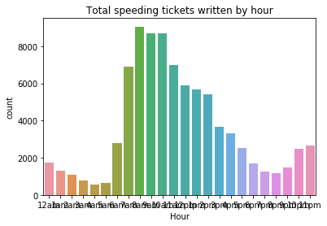

```python
graph2 = sns.countplot(x="Hour", order =['12am','1am','2am','3am','4am','5am',
                                        '6am','7am','8am','9am','10am','11am',
                                        '12pm','1pm','2pm','3pm','4pm','5pm',
                                        '6pm','7pm','8pm','9pm','10pm','11pm'],
                       data=speedingTicket).set_title("Total speeding tickets written by hour")
```

### Fixing the x axis ticks

Oh no! The hour ticks are unreadable! This is where the object-oriented interface of matplotlib comes into play, as I am only interested in making the x labels readable.

I also decided to rotate the y label for readability, and found that ylabel(rotation=-90) does not work because ylabel() requires an argument for the actual label, but I left it unchanged by using ylabel('count',rotation=0)

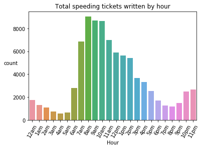

```python
graph2 = sns.countplot(x="Hour", order =['12am','1am','2am','3am','4am','5am',
                                        '6am','7am','8am','9am','10am','11am',
                                        '12pm','1pm','2pm','3pm','4pm','5pm',
                                        '6pm','7pm','8pm','9pm','10pm','11pm'],
                       data=speedingTicket).set_title("Total speeding tickets written by hour")
plt.xticks(rotation=60)
plt.ylabel('count',rotation=0)
plt.show()
```

## Answer to Question 3

At what hour are the MOST amount of speeding tickets written?

The 8am hour.

The 8am hour has the most amount of traffic tickets written. Most people work 9-to-5, frequently speeding to work when they are running late. Significantly fewer people start work at 10 or 11am. There is a lot less traffic after 9am, but cops are still looking to write tickets before their lunch break.

### Graph 3: Total speeding tickets by speed zone in Montgomery County since 2012

Since I'm not too sure what speed limit zones exist in Montgomery County, I just included intervals of 5mph up to the highest limit in the United States, which is 85mph in Texas, courtesy of googling "highest speed limit in USA".

[figure not shown]

```python
graph3 = sns.countplot(x='speedLimit', order=[5,10,15,20,25,
                                             30,35,40,45,50,
                                             55,60,65,70,75,
                                             80,85],
                      data=speedingTicket).set_title("Total speeding tickets written by speed zone")
```

## Answer to Question 4

For what speed limit zones do officers write the MOST amount of tickets?

30mph zones.

Graph 3 suggests that people speed proportionally more in slower areas. More importantly, Graph 3 indicates the common speed limits in Montgomery County. In the Bay Area there are little to no 55mph zones. Different states have different common speed limits.

### Running OLS regresions to answer Question 5

In a simple regression mphOverLimit on Gender, the coefficients are interpretted as averages. I will also regress speedingAt and speedLimit on Gender. The methods below are basic methods for running OLS and printing the results.

```python
model = smf.ols(formula='mphOverLimit ~ Gender', data=speedingTicket)
results = model.fit()
print(results.summary())
```

```
                            OLS Regression Results
==============================================================================
Dep. Variable:           mphOverLimit   R-squared:                       0.009
Model:                            OLS   Adj. R-squared:                  0.009
Method:                 Least Squares   F-statistic:                     827.0
Date:                Fri, 15 Jun 2018   Prob (F-statistic):          5.35e-181
Time:                        19:26:46   Log-Likelihood:            -2.9320e+05
No. Observations:               86387   AIC:                         5.864e+05
Df Residuals:                   86385   BIC:                         5.864e+05
Df Model:                           1
Covariance Type:            nonrobust
===============================================================================
                  coef    std err          t      P>|t|      [0.025      0.975]
-------------------------------------------------------------------------------
Intercept      13.6655      0.040    339.667      0.000      13.587      13.744
Gender[T.M]     1.4593      0.051     28.757      0.000       1.360       1.559
==============================================================================
Omnibus:                    30616.860   Durbin-Watson:                   1.688
Prob(Omnibus):                  0.000   Jarque-Bera (JB):           138813.575
Skew:                           1.689   Prob(JB):                         0.00
Kurtosis:                       8.211   Cond. No.                         3.04
==============================================================================

Warnings:
[1] Standard Errors assume that the covariance matrix of the errors is correctly specified.
```

```python
model = smf.ols(formula='speedingAt ~ Gender', data=speedingTicket)
results = model.fit()
print(results.summary())
```

```
                            OLS Regression Results
==============================================================================
Dep. Variable:             speedingAt   R-squared:                       0.012
Model:                            OLS   Adj. R-squared:                  0.012
Method:                 Least Squares   F-statistic:                     1016.
Date:                Fri, 15 Jun 2018   Prob (F-statistic):          1.12e-221
Time:                        19:27:27   Log-Likelihood:            -3.4437e+05
No. Observations:               86387   AIC:                         6.888e+05
Df Residuals:                   86385   BIC:                         6.888e+05
Df Model:                           1
Covariance Type:            nonrobust
===============================================================================
                  coef    std err          t      P>|t|      [0.025      0.975]
-------------------------------------------------------------------------------
Intercept      51.3465      0.073    705.736      0.000      51.204      51.489
Gender[T.M]     2.9253      0.092     31.876      0.000       2.745       3.105
==============================================================================
Omnibus:                    10693.153   Durbin-Watson:                   1.404
Prob(Omnibus):                  0.000   Jarque-Bera (JB):            15546.759
Skew:                           0.937   Prob(JB):                         0.00
Kurtosis:                       3.899   Cond. No.                         3.04
==============================================================================

Warnings:
[1] Standard Errors assume that the covariance matrix of the errors is correctly specified.
```

```python
model = smf.ols(formula='speedLimit ~ Gender', data=speedingTicket)
results = model.fit()
print(results.summary())
```

```
                            OLS Regression Results
==============================================================================
Dep. Variable:             speedLimit   R-squared:                       0.006
Model:                            OLS   Adj. R-squared:                  0.006
Method:                 Least Squares   F-statistic:                     514.9
Date:                Fri, 15 Jun 2018   Prob (F-statistic):          1.16e-113
Time:                        19:31:48   Log-Likelihood:            -3.1405e+05
No. Observations:               86387   AIC:                         6.281e+05
Df Residuals:                   86385   BIC:                         6.281e+05
Df Model:                           1
Covariance Type:            nonrobust
===============================================================================
                  coef    std err          t      P>|t|      [0.025      0.975]
-------------------------------------------------------------------------------
Intercept      37.6810      0.051    735.712      0.000      37.581      37.781
Gender[T.M]     1.4659      0.065     22.692      0.000       1.339       1.593
==============================================================================
Omnibus:                     8483.841   Durbin-Watson:                   1.313
Prob(Omnibus):                  0.000   Jarque-Bera (JB):             7706.826
Skew:                           0.661   Prob(JB):                         0.00
Kurtosis:                       2.371   Cond. No.                         3.04
==============================================================================

Warnings:
[1] Standard Errors assume that the covariance matrix of the errors is correctly specified.
```

## Answer to Question 5

Do men tend to drive faster than women?

Yes.

The base case in the regressions are female, where the intercepts show the average for each measure. All three of the coefficients for the males are positive. Given that they are already speeding, males will drive slightly faster at about 1.5mph over females. For any speed, males drive almost 3mph faster than females. Lastly, males choose a combination of routes whose average speed limit is about 1.5mph faster than the route a female would choose. Men drive faster than women, for reasons beyond the scope of this project.

Thanks for reading!

-Maxwell